# TCGA survival analysis

Rafal Cylwa

5 marca 2017

# Intro

This report provides an overview of survival analysis of cancer patients based on the TCGA data. The aim was to identify pairs of (cancer cohort, gene) which possibly indicate the difference in survival time in groups of patients with high and low expression of a given gene.

TCGA data used for the analysis is obtained via RTCGA family of R packages.

# Data download and preparation

Packages used:

```r
library(RTCGA)          # Functions for querying the data
library(RTCGA.rnaseq)   # Gene expression data
library(RTCGA.clinical) # Clinical data
library(survival)       # Survival analysis tools
library(survminer)      # Survival analysis tools
library(tidyverse)
library(knitr)
library(pheatmap)
```

Steps of data preparation (R script avialable in /scripts)

1. Genenes selected for investigation

```r
selected_genes <- c("ZNF695",
                    "ZNF643",
                    "ZNF789",
                    "ZNF320",
                    "ZNF273",
                    "ZNF707",
                    "ZNF205",
                    "ZNF468",
                    "ZNF714",
                    "ZNF485",
                    "ZNF525",
                    "ZNF267",
                    "ZNF282",
                    "ZNF114")
```

2. Extractiong column names for selected genes
3. Downloading expressions
4. Downloading survival times
5. Joining survival times with gene expressions
6. Check for join multiplicates
7. We remove SKCM.rnaseq, because there is only one observation.
8. Shorten gene names
9. Data overview

| dataset | n_of_observations |
| --- | --- |
| ACC | 79 |
| BLCA | 403 |
| BRCA | 1091 |
| CESC | 304 |
| CHOL | 36 |
| COAD | 282 |
| COADREAD | 376 |
| DLBC | 15 |
| ESCA | 183 |
| GBM | 152 |
| GBMLGG | 663 |
| HNSC | 518 |
| KICH | 64 |
| KIPAN | 883 |
| KIRC | 532 |
| KIRP | 287 |
| LGG | 511 |
| LIHC | 369 |
| LUAD | 496 |
| LUSC | 487 |
| OV | 300 |
| PAAD | 178 |
| PCPG | 179 |
| PRAD | 497 |
| READ | 94 |
| SARC | 257 |
| STAD | 36 |
| STES | 219 |
| TGCT | 133 |
| THCA | 500 |
| THYM | 119 |
| UCEC | 174 |
| UCS | 57 |
| UVM | 80 |

# Data analysis

## Categorisation of gene expressions

In order to use log-rank test for comparing two survival curves we need to split gene expressions variables into categorical variables (high/low expression).

For our analysis we use two methods for splitting. One is to use median as a cutpoint and second is to use a cutpoint selected using maximally selected rank statistics [maximally selected rank statistics](https://cran.r-project.org/web/packages/maxstat/vignettes/maxstat.pdf)

Note that each cutpoint is calculated in groups (for each combination of gene/cohort).

Cutpoints obtained using maximally selected rank statistics:

|  | ZNF695 | ZNF643 | ZNF789 | ZNF320 | ZNF273 | ZNF707 | ZNF205 | ZNF468 | ZNF714 | ZNF485 | ZNF525 | ZNF267 | ZNF282 | ZNF114 |
| --- | --- | --- | --- | --- | --- | --- | --- | --- | --- | --- | --- | --- | --- | --- |
| ACC | 13.5524 | 17.1038 | 138.9831 | 479.7433 | 64.9918 | 405.7300 | 528.1063 | 186.7443 | 128.3237 | 34.9286 | 125.9982 | 149.7849 | 777.2845 | 3.8241 |
| BLCA | 37.6285 | 25.1572 | 72.5894 | 1134.3720 | 130.4807 | 205.2003 | 208.2123 | 221.7537 | 105.1213 | 100.3836 | 186.4669 | 439.9510 | 1294.8975 | 60.8650 |
| BRCA | 41.1877 | 32.0919 | 110.4221 | 679.5941 | 208.7387 | 161.7473 | 304.6032 | 710.9228 | 396.8301 | 152.2222 | 337.4101 | 248.1545 | 501.1241 | 24.7530 |
| CESC | 133.2470 | 56.0811 | 137.1003 | 354.1958 | 142.6365 | 197.4919 | 247.2986 | 332.9640 | 108.3196 | 33.7171 | 222.4658 | 485.8830 | 969.8737 | 69.7407 |
| CHOL | 5.7997 | 9.6878 | 61.9868 | 308.3155 | 80.7099 | 152.9635 | 473.0303 | 351.0577 | 91.2126 | 96.3205 | 152.6598 | 323.0950 | 776.6323 | 1.0488 |
| COAD | 93.7091 | 77.6899 | 82.1918 | 638.4810 | 130.8467 | 246.3273 | 226.6601 | 527.7651 | 274.5755 | 48.7546 | 214.5125 | 366.7762 | 1287.5949 | 0.8839 |
| COADREAD | 93.7091 | 39.7709 | 82.1918 | 638.4810 | 130.8467 | 246.6960 | 314.7574 | 553.3118 | 274.9208 | 114.1414 | 214.5125 | 360.1799 | 1257.8526 | 30.6074 |
| READ | 117.7820 | 81.9518 | 174.5574 | 255.0505 | 164.4089 | 320.6215 | 276.6005 | 534.3761 | 94.1638 | 91.4318 | 276.1299 | 266.6256 | 1034.9498 | 0.8258 |
| DLBC | 21.7647 | 34.2703 | 82.7878 | 565.4618 | 273.2342 | 251.4440 | 36.2601 | 408.4911 | 214.8481 | 96.6543 | 371.3057 | 1119.5204 | 676.9349 | 0.9180 |
| ESCA | 43.2629 | 87.7386 | 86.6163 | 122.2640 | 167.4192 | 280.6892 | 308.9942 | 629.2933 | 509.1206 | 130.4556 | 108.7304 | 288.0734 | 745.9119 | 6.6735 |
| STES | 43.2629 | 87.7386 | 60.1802 | 392.6820 | 167.4192 | 280.6892 | 308.9942 | 725.2935 | 509.1206 | 134.0046 | 314.8561 | 602.4390 | 758.6085 | 0.9117 |
| LUAD | 1.8570 | 24.9629 | 37.0882 | 710.4208 | 116.6395 | 168.0726 | 455.2404 | 271.1461 | 157.7564 | 35.8901 | 275.9114 | 248.1969 | 838.5224 | 17.7906 |
| KIPAN | 8.8872 | 29.7063 | 101.0249 | 630.9891 | 63.6126 | 145.6241 | 255.2322 | 526.6913 | 44.9882 | 54.0719 | 331.7422 | 278.5700 | 693.8868 | 31.4334 |
| KIRC | 7.2533 | 29.8953 | 100.7260 | 650.1506 | 83.5884 | 151.3525 | 414.2466 | 284.6163 | 47.7787 | 56.1694 | 162.1303 | 399.1361 | 813.7438 | 31.4334 |
| GBM | 24.8343 | 37.8021 | 147.6461 | 721.1312 | 215.0033 | 105.3985 | 361.1968 | 274.0538 | 108.0711 | 48.6155 | 77.6119 | 324.4755 | 680.3279 | 25.9230 |
| GBMLGG | 3.4602 | 32.7771 | 169.8961 | 450.5983 | 277.4086 | 184.0187 | 535.9316 | 192.6821 | 249.0842 | 31.7726 | 108.5098 | 287.7514 | 889.4472 | 99.3007 |
| LGG | 2.3522 | 84.7917 | 74.4585 | 456.6511 | 277.4086 | 231.3261 | 554.2715 | 196.1901 | 364.5437 | 31.7187 | 106.3906 | 300.4222 | 745.9939 | 44.3367 |
| HNSC | 33.6451 | 28.1343 | 37.5370 | 56.7792 | 47.8319 | 494.0919 | 524.3965 | 240.6493 | 194.8553 | 78.7037 | 25.1667 | 327.9003 | 1427.3537 | 35.6537 |
| KICH | 13.2190 | 3.5920 | 58.1717 | 574.7863 | 143.0905 | 159.7836 | 200.4667 | 854.1687 | 407.7634 | 10.5226 | 636.8980 | 114.6461 | 538.0747 | 1.5760 |
| KIRP | 12.9862 | 11.5931 | 51.4706 | 434.9385 | 45.4223 | 245.3852 | 426.2993 | 249.4452 | 28.6134 | 53.8533 | 101.0962 | 278.5700 | 1253.5298 | 0.8111 |
| LIHC | 0.5301 | 37.2534 | 38.0854 | 281.2555 | 50.7890 | 184.0722 | 261.5912 | 240.4130 | 57.1561 | 20.8535 | 125.9669 | 81.1787 | 701.1446 | 1.4556 |
| LUSC | 69.3284 | 23.6132 | 41.0610 | 286.3764 | 174.3970 | 139.9980 | 206.8892 | 309.2764 | 292.7715 | 79.0375 | 387.7286 | 595.5176 | 568.6803 | 2.6326 |
| OV | 184.3391 | 19.6780 | 159.2112 | 753.3373 | 184.8124 | 181.5728 | 299.6024 | 330.3611 | 217.9786 | 109.1875 | 242.5349 | 303.0141 | 1610.9966 | 2.2526 |
| PAAD | 0.8180 | 16.8350 | 133.5321 | 470.4218 | 59.5122 | 264.1904 | 161.3679 | 532.9396 | 60.4555 | 30.8552 | 323.5159 | 274.9100 | 569.0578 | 16.3432 |
| PCPG | 4.0733 | 32.7511 | 74.9263 | 475.3684 | 119.4770 | 141.6630 | 231.1759 | 133.5846 | 208.8963 | 39.3500 | 131.9561 | 199.1814 | 779.9305 | 2.9142 |
| PRAD | 22.4776 | 19.5080 | 182.6134 | 576.0300 | 66.1600 | 213.9535 | 593.3990 | 422.6121 | 213.6247 | 75.3473 | 299.3777 | 153.1117 | 929.8311 | 5.7899 |
| SARC | 25.5573 | 39.3736 | 120.5788 | 291.9021 | 96.7514 | 311.2401 | 442.5071 | 261.7870 | 238.1857 | 30.7626 | 124.3842 | 534.3639 | 1142.2187 | 31.4039 |
| STAD | 4.5858 | 67.9814 | 91.6351 | 350.4587 | 112.4324 | 208.8332 | 225.4614 | 587.2576 | 421.7437 | 47.3870 | 90.5808 | 285.9659 | 758.6085 | 0.7024 |
| TGCT | 240.9905 | 224.3893 | 169.7661 | 776.5858 | 687.9664 | 531.8011 | 418.7966 | 612.3937 | 529.3843 | 71.8284 | 955.4475 | 523.7698 | 1094.9432 | 69.8529 |
| THCA | 3.0892 | 43.9018 | 48.2166 | 543.6090 | 129.5294 | 160.8240 | 270.9429 | 235.9975 | 391.8152 | 22.6555 | 100.4098 | 396.0519 | 685.9160 | 203.0899 |
| THYM | 81.2516 | 18.2904 | 110.1157 | 278.2516 | 159.7611 | 297.3554 | 439.3728 | 276.1916 | 44.0478 | 54.3950 | 254.7183 | 421.5184 | 865.4344 | 10.2301 |
| UCEC | 119.1599 | 21.0000 | 176.1566 | 369.6185 | 75.5562 | 244.8759 | 333.9596 | 292.4394 | 372.3449 | 36.9928 | 398.6388 | 205.5800 | 1487.0629 | 4.0323 |
| UCS | 253.1902 | 93.5076 | 139.8797 | 378.2074 | 219.3362 | 270.7260 | 446.4434 | 235.7111 | 115.0885 | 40.0330 | 100.2342 | 172.2320 | 655.7462 | 13.4012 |
| UVM | 9.9267 | 12.0539 | 78.7935 | 411.4088 | 99.3870 | 641.4304 | 324.5295 | 79.9916 | 45.6130 | 68.3012 | 179.0885 | 178.8994 | 1935.8354 | 47.1850 |

**Cutpoints obtained using medians**

| dataset | ZNF695 | ZNF643 | ZNF789 | ZNF320 | ZNF273 | ZNF707 | ZNF205 | ZNF468 | ZNF714 | ZNF485 | ZNF525 | ZNF267 | ZNF282 | ZNF114 |
| --- | --- | --- | --- | --- | --- | --- | --- | --- | --- | --- | --- | --- | --- | --- |
| ACC | 4.57670 | 18.26890 | 65.80890 | 371.5481 | 94.87080 | 260.7744 | 384.0633 | 286.60700 | 144.23450 | 39.02150 | 230.6226 | 161.07380 | 718.6441 | 18.38090 |
| BLCA | 55.39690 | 41.00570 | 92.35130 | 611.8058 | 166.76590 | 298.0080 | 340.5401 | 466.06510 | 145.90960 | 60.69800 | 273.6099 | 327.49080 | 1151.1725 | 17.79700 |
| BRCA | 35.81420 | 47.88680 | 69.76740 | 537.5079 | 172.85480 | 266.2315 | 304.0768 | 500.71740 | 177.85750 | 86.36190 | 326.8409 | 379.66640 | 728.1288 | 5.52690 |
| CESC | 66.03905 | 30.85615 | 123.86450 | 212.4275 | 120.68565 | 288.1254 | 396.9140 | 311.24245 | 149.00380 | 44.01705 | 216.0055 | 382.92220 | 927.2707 | 46.00635 |
| CHOL | 9.38595 | 26.83830 | 95.76355 | 546.5112 | 81.34505 | 279.1318 | 438.7728 | 480.88505 | 86.13525 | 75.84930 | 206.3800 | 299.76035 | 975.4960 | 2.19900 |
| COAD | 56.11285 | 47.81335 | 112.97765 | 484.0390 | 111.53325 | 227.0582 | 323.9370 | 502.32665 | 153.65200 | 85.23895 | 207.4518 | 350.37955 | 939.5089 | 4.07195 |
| COADREAD | 55.21890 | 48.91260 | 114.03790 | 484.8668 | 113.82945 | 231.4810 | 319.6178 | 507.81270 | 152.09125 | 85.75415 | 227.9812 | 355.61775 | 944.2114 | 4.12340 |
| DLBC | 17.79800 | 37.09250 | 175.18590 | 353.6854 | 208.53310 | 347.1429 | 38.9312 | 277.14290 | 179.04860 | 87.85710 | 208.1784 | 957.33460 | 788.9845 | 1.10010 |
| ESCA | 57.95490 | 48.15760 | 94.55080 | 319.1851 | 167.41920 | 191.5474 | 257.1679 | 340.86240 | 306.23330 | 62.66100 | 156.3591 | 478.00390 | 874.2173 | 22.63720 |
| GBM | 4.13580 | 39.45155 | 133.34765 | 477.7987 | 237.76675 | 165.4587 | 318.5251 | 236.68175 | 178.22870 | 28.57305 | 102.4320 | 273.40645 | 867.9384 | 64.24785 |
| GBMLGG | 8.07440 | 46.94760 | 101.02050 | 401.1903 | 203.27720 | 213.3132 | 345.3393 | 133.69780 | 252.18080 | 37.53350 | 80.3797 | 226.55760 | 857.9147 | 54.11370 |
| HNSC | 19.87440 | 37.24730 | 47.24925 | 140.1728 | 101.45950 | 318.3714 | 307.0445 | 261.50635 | 98.14185 | 43.26070 | 135.9057 | 411.91835 | 1061.3465 | 65.46595 |
| KICH | 4.17970 | 4.71710 | 36.45485 | 709.7993 | 110.81315 | 201.7873 | 364.7158 | 874.79455 | 295.58070 | 15.36045 | 399.1436 | 176.22935 | 702.8828 | 8.15070 |
| KIPAN | 3.35980 | 21.95000 | 87.58410 | 1020.8184 | 70.64760 | 152.3361 | 361.3642 | 389.26170 | 75.71450 | 43.22770 | 208.3212 | 362.59260 | 669.1561 | 6.06090 |
| KIRC | 3.43220 | 25.85310 | 87.59545 | 1110.2584 | 65.20860 | 129.0370 | 328.6197 | 398.12810 | 78.49730 | 52.08850 | 223.2423 | 426.51210 | 600.9410 | 8.91245 |
| KIRP | 3.17960 | 17.34510 | 119.17300 | 980.7461 | 82.60390 | 189.4764 | 451.2606 | 336.96240 | 56.39170 | 32.95850 | 161.1271 | 279.13570 | 848.1288 | 2.86940 |
| LGG | 8.69610 | 49.39030 | 93.01470 | 378.0048 | 197.27670 | 228.2514 | 362.7672 | 116.12820 | 275.80230 | 41.26520 | 76.4636 | 214.60780 | 857.3482 | 51.81860 |
| LIHC | 1.26280 | 19.81770 | 72.46380 | 139.4813 | 37.02050 | 200.1358 | 318.7615 | 183.39740 | 21.47240 | 39.61670 | 69.0131 | 139.14080 | 759.5517 | 1.84310 |
| LUAD | 16.80745 | 38.58460 | 82.55375 | 477.5593 | 131.83670 | 232.2317 | 277.9214 | 434.31055 | 180.52735 | 57.95845 | 190.1596 | 391.27730 | 733.8367 | 15.25460 |
| LUSC | 52.32940 | 48.95610 | 86.57430 | 287.5008 | 183.20940 | 261.3042 | 246.1825 | 365.16650 | 166.26010 | 51.87820 | 238.1848 | 426.17830 | 931.7450 | 24.47910 |
| OV | 82.50060 | 45.98915 | 119.56695 | 457.2094 | 209.28670 | 347.8374 | 446.6301 | 267.43470 | 329.97195 | 91.77680 | 170.5825 | 258.14105 | 1339.3078 | 10.84365 |
| PAAD | 6.03660 | 25.96830 | 103.48495 | 419.2163 | 91.60095 | 238.5402 | 361.4432 | 347.60110 | 81.04045 | 50.79560 | 199.1255 | 445.62825 | 818.4164 | 6.51780 |
| PCPG | 1.06300 | 21.67180 | 70.37360 | 338.0391 | 56.40310 | 153.1619 | 378.2247 | 114.95480 | 98.42880 | 25.10040 | 129.4569 | 147.63950 | 540.1372 | 2.87150 |
| PRAD | 7.87990 | 30.24030 | 122.69550 | 555.9705 | 87.33620 | 220.8901 | 367.7533 | 420.77750 | 138.47330 | 80.49790 | 311.6432 | 155.39070 | 1075.5814 | 2.34840 |
| READ | 51.08200 | 53.81235 | 115.67790 | 494.2496 | 123.07210 | 249.0764 | 301.6316 | 521.46760 | 144.61385 | 87.96295 | 267.4578 | 381.66415 | 959.8034 | 4.29305 |
| SARC | 13.17470 | 36.82630 | 73.18410 | 363.9500 | 116.47140 | 234.6613 | 403.2935 | 186.07520 | 101.71680 | 33.80280 | 124.1756 | 298.10180 | 934.1085 | 15.69260 |
| STAD | 50.39940 | 51.72035 | 92.01475 | 398.5734 | 112.38095 | 185.1175 | 257.1717 | 465.52385 | 258.44365 | 61.06590 | 209.2262 | 495.87195 | 852.9116 | 5.69955 |
| STES | 57.24000 | 48.79540 | 94.35640 | 335.8714 | 158.99650 | 190.7514 | 257.1679 | 353.98300 | 298.25520 | 61.77610 | 159.6811 | 482.31990 | 863.3507 | 15.32910 |
| TGCT | 205.46400 | 102.68490 | 148.16500 | 772.3120 | 841.64860 | 359.2767 | 406.6032 | 467.16790 | 438.32360 | 123.50880 | 554.3294 | 489.09300 | 815.4667 | 132.54110 |
| THCA | 3.48045 | 34.93840 | 73.35835 | 418.6057 | 170.60855 | 218.8245 | 348.3640 | 385.03125 | 387.45980 | 32.27385 | 147.7005 | 276.83075 | 635.6639 | 174.54300 |
| THYM | 34.68460 | 25.23430 | 169.04000 | 395.5590 | 166.04240 | 351.8105 | 341.9270 | 220.99870 | 143.08130 | 50.61690 | 238.9023 | 279.02620 | 981.6066 | 9.38230 |
| UCEC | 122.25655 | 40.54370 | 146.23165 | 700.2405 | 164.99865 | 290.5149 | 544.7861 | 360.16900 | 165.30625 | 69.44235 | 242.2034 | 259.57845 | 1139.3367 | 25.78640 |
| UCS | 147.98400 | 52.26130 | 128.24880 | 552.5890 | 195.96660 | 396.1112 | 546.0260 | 225.76180 | 188.28050 | 75.69910 | 189.0651 | 239.21430 | 1049.6300 | 29.08590 |
| UVM | 5.73825 | 20.07800 | 65.03550 | 242.7931 | 46.27870 | 444.8644 | 583.3197 | 82.27815 | 28.86065 | 53.82010 | 73.0601 | 74.25925 | 1223.1123 | 18.95840 |

## Log-rank tests

Now, for each pair [gene, cohort] we calculate p-values of log-rank tests.

Low p-value indicates that there is a significant difference in survival time for two groups i.e. high/low expression.

Heatmap of p-values for log-rank test using cutpoint via maximally selected rank statistics.

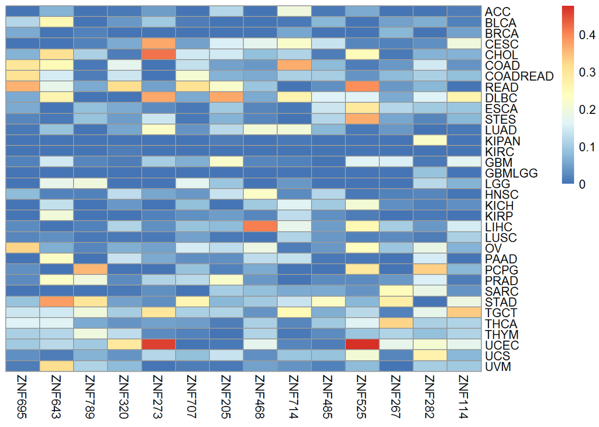

Heatmap of p-values for log-rank test using median cutpoint.

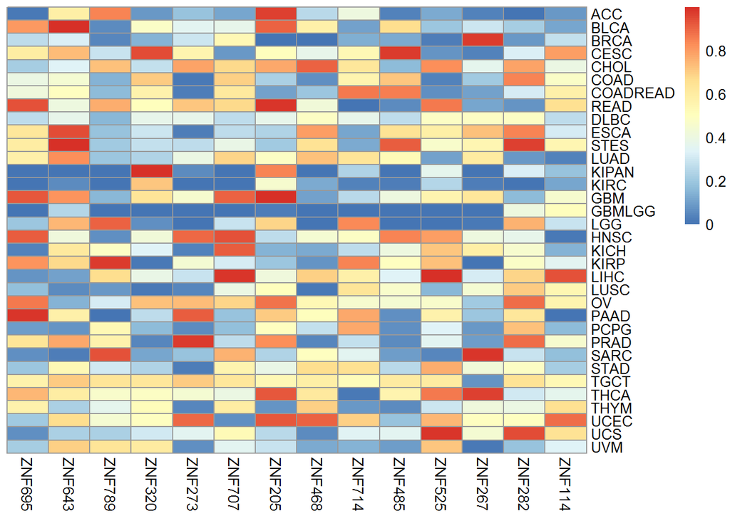

## Examples of Kaplan-Meier survival curves for some interesting cases

In these case p < 0.05 and we observe that survival curves differs i.e. lower expression = longer survival.

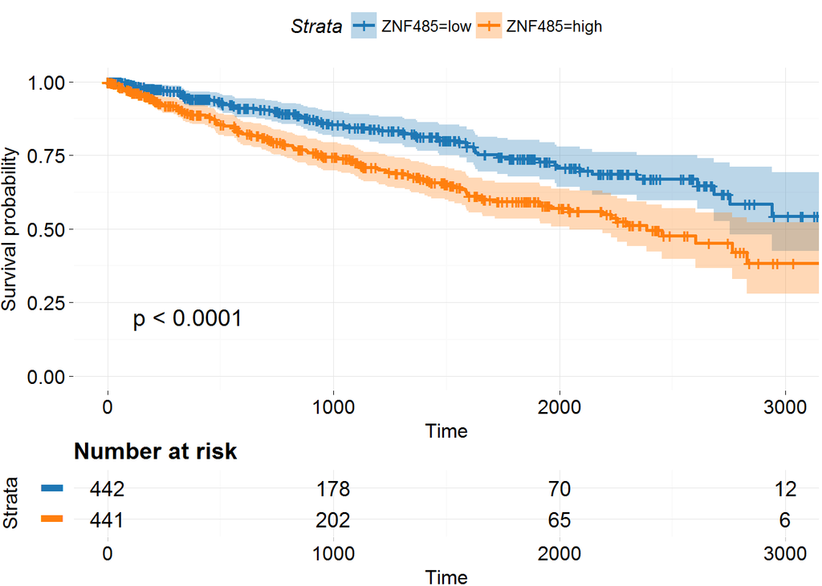

### KIRC/ZNF468/median

In these case p > 0.05 and we observe that survival curves are realively close to each other.

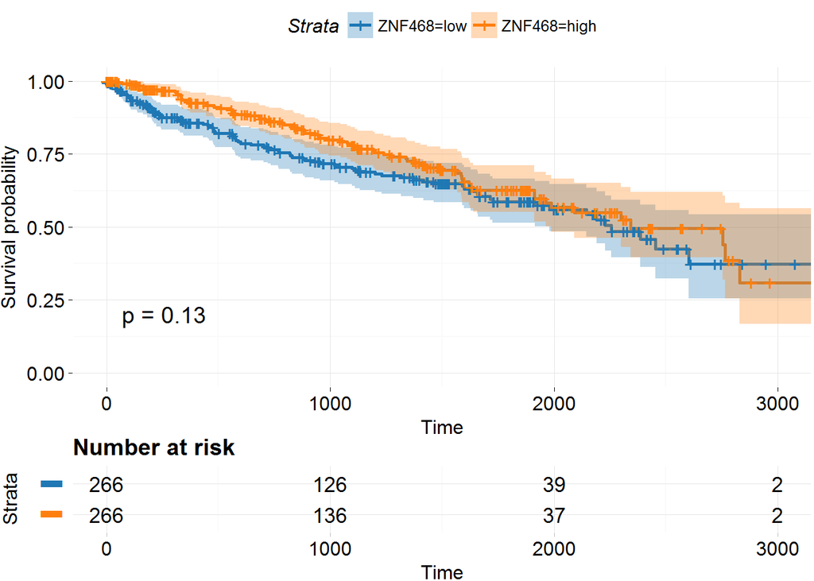